# Reproducible Analytical Pipelines Demo

28 November 2016

# Government Digital Service:

## Better Use of Data Team

**Date**: August 2016  
**Contact**: gdsdatascience@digital.cabinet-office.gov.uk

# Introduction

**Released:** 4 August 2016

**Geographic Coverage:** United Kingdom

## Background

This release provides an estimate of the contribution of DCMS sectors to the UK economy, measured by gross value added (GVA) (2010 - 2015), exports of services (2010 - 2014), imports of services (2013 - 2014) and number of enterprises (2008 - 2014). The DCMS sectors cover:

- Creative Industries
- Cultural Sector
- Digital Sector
- Gambling
- Sport
- Telecoms
- Tourism

A definition for each sector is available in the associated methodology note, along with details of methods and data limitations. There is significant overlap between DCMS sectors so users should be aware that the estimate for “all DCMS sectors” is lower than the sum of the individual sectors.

This release supersedes the publication in September 2015 where an estimate for DCMS sectors was produced. It is the first time it has been possible to look at the changes over time for all DCMS sectors in a consistent way, and the first official estimates across sectors for the range of additional measures presented in this report.

DCMS is grateful to the Office for National Statistics for all their support with this work.

## Limitations

The estimates set out in this report differ from those previously published by DCMS for a number of sector.

## Office for Civil Society

Responsibility for the Office for Civil Society was transferred from Cabinet Office to DMCS on 21 July 2016. The Office for Civil Society leads cross-government work in support of the voluntary, community and social enterprise sector (VCSE). The estimates included in this report do not currently attempt to measure the value of this sector (though some elements will be included through the sectors which are covered e.g. Sport and Culture).

## Creative Industries

Estimates in this report are experimental, but it is intended this approach will replace the previous methodology, subject to user feedback. There is no difference between the two sources for data on exports and number of enterprises.

## Sport

For the purposes of this publication the statistical definition of sport has been used, this incorporates only those 4-digit SIC codes which are predominately sport (see methodology note Table 2.1). DCMS also publishes estimates of sport based on the EU Sectors agreed Vilnius definition. The Vilnius definition is a more comprehensive measure of sport which considers the contribution of sport across of range of industries, for example sport advertising, and sport related construction. The DCMS Sport Satellite Account, based on the EU agreed methodology, should continue to be used as the best headline measure of sport’s contribution to the UK economy.

## Tourism

Estimates for tourism used in this publication are based on a different methodology to all other sectors, as they are taken from the Tourism Satellite Account. This is an internationally recommended methodology for measurement of the contribution of tourism to the economy.

## 2015 GVA

For 2015, the GVA data is taken from the output measure of GVA to allow consistency with the sector measures. This is aligned to average GVA up to and including 2014 (last Supply Use balanced year) but then uses growth in the output measure as a proxy for GVA beyond that. The 2015 figure therefore differs from National Account GVA at current basic prices (series named ABML).

Estimates have been constructed from ONS Official Statistics which use international classifications, this is an important element of the methodology due to availability of data and to enable international comparability. However, as a result there are substantial limitations to the underlying classifications. As the balance and make-up of the economy changes the international classifications are less able to provide the detail for important elements of the UK economy related to DCMS sectors, and therefore best fit SIC codes have been used to produce these estimates. More details of limitations are available in the methodology note.

## Feedback and consultation

DCMS aims to continuously improve the quality of estimates and better meet user needs. DCMS welcomes feedback on this experimental release and will be publishing a request for user feedback on specific topics, including the definition of Culture, on 9 August. Feedback and responses should be sent to DCMS via email at evidence@culture.gov.uk by 14 October 2016.

# Key Findings

## GVA

- In 2015 the contribution of DCMS sectors to the UK economy (GVA) was £221bn, or 13.3 per cent of UK GVA.
- The GVA of DCMS sectors has grown at a faster rate than the economy as a whole, increasing by 3.6 per cent since 2014 (£213bn), and 24.8 per cent since 2010 (£177bn),compared with increases of 2.3 per cent and 17.4 per cent for the whole UK economy.
- The Cultural Sector had the greatest percentage increase between 2014 and 2015 (15.0%), whilst Sport had the greatest percentage increase since 2010 (44.4%).

## Exports and Imports

- In 2014, DCMS sectors exported £37.7bn worth of services to the rest of the world, 17.2 per cent of total UK service exports. This was 13.7 per cent higher than 2013, and 40.5 per cent higher than 2010, a much faster rate than growth than was seen for UK exports of services as a whole (which were 2.0% and 25.6% respectively).
- In 2014, 42.3 per cent of exports of services from DCMS sectors went to countries in the European Union (EU): this compares to 38.6 per cent of all UK exports of services.
- In 2014, DCMS sectors imported £19.4bn worth of services from the rest of the world, 14.6 per cent of total UK imports of services. This was a 9.0 per cent increase from 2013, compared with a 0.5 per cent decrease for the UK as a whole.
- In 2014, 53.7 per cent of imports of services for DCMS sectors came from countries in the European Union (EU), this compares to 47.8 per cent of total UK service imports.

## Number of enterprises

# GVA

This chapter presents UK GVA estimates for each DCMS sector at a headline level. All estimates of GVA are shown in current prices (i.e. not adjusted for inflation). GVA estimates are consistent with the Office for National Statistics National Accounts. Where data are not available directly from the Supply and Use tables the Annual Business Survey (ABS) has been used to allocate GVA within the categories available in the Supply and Use tables. Further information on the methodology is available in the associated methodology note.

## Summary

It is estimated that in 2015 the contribution of DCMS sectors to the UK economy (GVA) was £221bn[^1], or 13.3 per cent of UK GVA. The GVA of DCMS sectors has grown at a faster rate than the economy as a whole, increasing by 3.6 per cent since 2014 (£213bn), and 24.8 per cent since 2010 (£177bn). This compares to increases of 2.3 per cent and 17.4 per cent respectively for the UK economy as a whole.

|  | sector | X2010 | X2011 | X2012 | X2013 | X2014 | X2015 | since_2014 | since_2010 | UK_perc |
| --- | --- | --- | --- | --- | --- | --- | --- | --- | --- | --- |
| 1 | Creative Industries | 65.2 | 69.4 | 73.0 | 77.9 | 81.6 | 87.3 | 7.00 | 34.00 | 5.30 |
| 2 | Cultural Sector | 20.3 | 21.0 | 21.8 | 23.5 | 23.5 | 27.0 | 15.00 | 33.00 | 1.60 |
| 3 | Digital Sector | 97.3 | 103.0 | 105.2 | 110.0 | 111.6 | 118.4 | 6.10 | 21.70 | 7.10 |
| 4 | Gambling | 8.4 | 9.3 | 9.8 | 9.9 | 10.2 | 10.3 | 0.90 | 22.50 | 0.60 |
| 5 | Sport | 7.0 | 7.4 | 7.9 | 9.8 | 10.3 | 10.1 | -1.50 | 44.40 | 0.60 |
| 6 | Telecoms | 24.7 | 25.4 | 26.0 | 28.0 | 29.1 | 30.2 | 4.00 | 22.30 | 1.80 |
| 7 | Tourism | 49.1 | 53.9 | 57.3 | 59.0 | 60.4 | 62.4 | 3.30 | 27.00 | 3.80 |
| 8 | All DCMS sectors | 177.1 | 189.8 | 197.9 | 209.4 | 213.3 | 220.9 | 3.60 | 24.80 | 13.30 |
| 9 | % of UK GVA | 12.5 | 13.1 | 13.2 | 13.5 | 13.1 | 13.3 |  |  |  |
| 10 | UK | 1414.6 | 1452.1 | 1495.6 | 1551.6 | 1624.3 | 1661.1 | 2.30 | 17.40 | 100.00 |

[figure not shown]

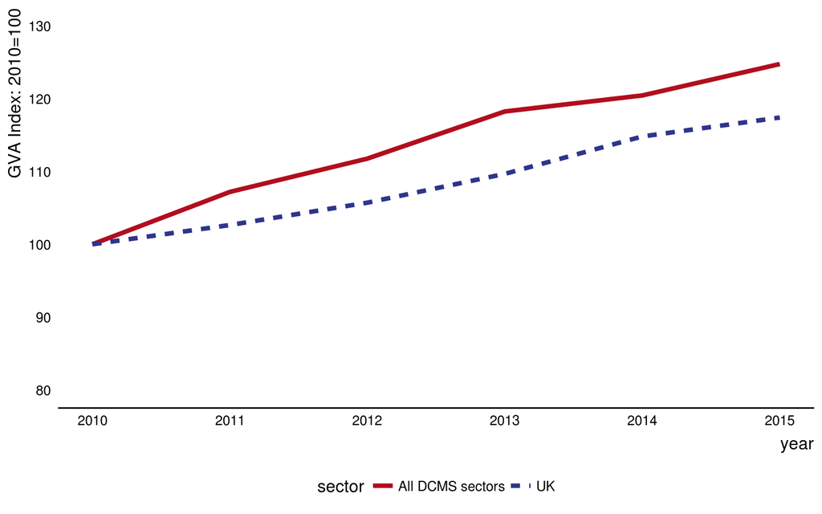

The Cultural Sector had the greatest percentage increase between 2014 and 2015 (15.0%), whilst Sport had the greatest percentage increase since 2010 (44.4%), despite a small decrease between 2014 and 2015 (of 1.5%). Creative Industries had the second greatest increase over the past five years (34.0%). Figures 3.2 and 3.3 show the growth rate for DCMS sectors as a whole and for each DCMS sector.

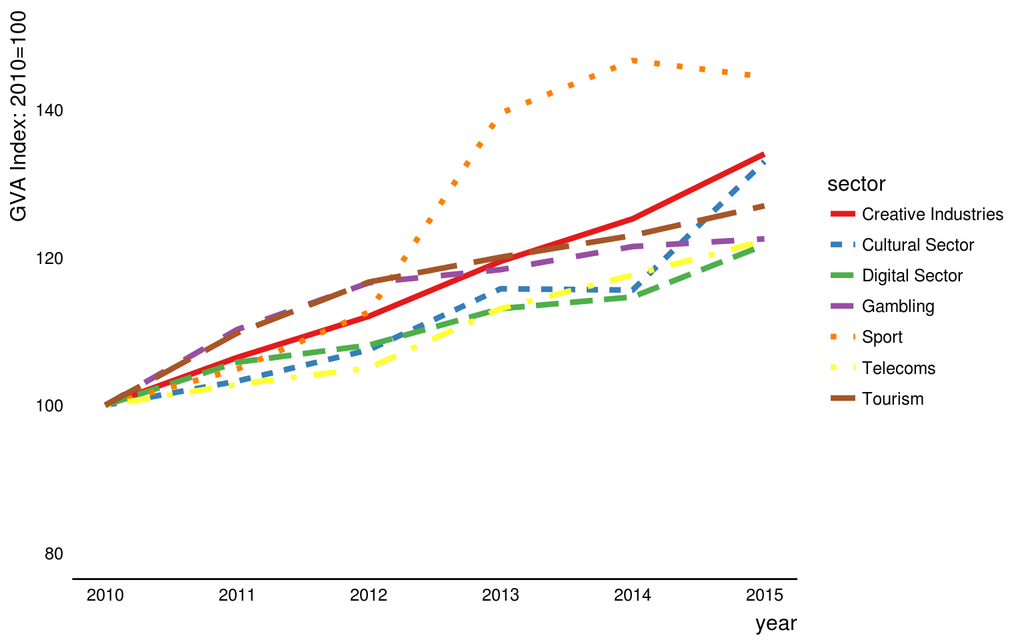

# Exports and Imports of Services

This section provides estimates of exports and imports of services from and to DCMS sectors. Estimates are given in current prices (i.e. not adjusted for inflation) and are based on data from the International Trade in Services survey, except estimates for Tourism, which are based on the International Passenger Survey. Further information on methodology is available in the methodology note. Latest data available for exports and imports are for 2014.

## Exports

In 2014, DCMS sectors exported £37.7bn worth of services to the rest of the world: 17.2 per cent of total UK service exports. This was a 13.7 per cent increase from 2013, and a 40.5 per cent increase since 2010.

Growth in service exports for DCMS sectors has been greater than in service exports by all UK industries: the value of services exported by all UK industries increased by 2.0 per cent between 2013 and 2014, and by 25.6 per cent compared to 2010.

The greatest contribution to UK and DCMS sector service exports was from the Digital Sector (14.5% of total UK service exports in 2014), followed by the Creative Industries (9.1% of total UK service exports in 2014). Gambling is the only sector which has not growth in service exports since 2010 (50.9% decrease since 2013 and an 11.9% decrease since 2010). High variation in Gambling is expected because the number of enterprises in the sector and the value of exports is relatively small. Some of the change may also be due to changes in regulations on where firms must be located in order to operate in the UK, which applied from late 2014.

### Exports by continent and EU

More data on exports of services for the Digital Sector and Creative Industries, presented by Standard Industrial Classification code, are available in an ad hoc statistic release published by DCMS in April 2016[^2].

## Exports by the Tourism sector

Estimates of exports for Tourism are based on data from the International Passenger Survey. It is assumed that exports of tourism is equal to the spend by overseas residents during visits to the UK. These figures represent exports of services and exports of goods combined and therefore are not directly comparable with the exports of services figures presented in the rest of this chapter.

## Imports

In 2014, DCMS sectors imported £19.4bn worth of services from the rest of the world: 14.6 per cent of total UK imports of services. This was a 9.0 per cent increase from 2013.

### Imports by the Tourism sector

Estimates of imports for the Tourism sector are based on data from the International Passenger Survey. It is assumed that imports of tourism is equal to spend by UK residents travelling overseas. These figures represent imports of services and goods combined and therefore are not directly comparable with the imports of services figures presented in the rest of this chapter.

In 2014, the UK Tourism sector imported £35.5bn from the rest of the world. This accounted for 6.5 per cent of total UK imports of goods and services.

Visits to countries in the European Union were responsible for 55.6 per cent of Tourism imports in 2014 (£19.8bn).

# Enterprises

This section provides estimates of the number of enterprises for DCMS sectors. These data are from the Annual Business Survey (ABS) and are based on the ABS definition of enterprises[^4]. For further context the percentage of those enterprises in each size band (small, medium, and large) is also presented. These are based on an extract from the Inter Departmental Business Register (IDBR)[^5]. Further information on methodology are available in the published methodology note.

## Summary

In 2014, DCMS sectors accounted for 15.8 per cent of all UK enterprises, approximately 331 thousand enterprises. The number of enterprises in all DCMS sectors has increased by 4.1 per cent between 2013 and 2014, and by 19.5 per cent since 2008.

Amongst the individual DCMS sectors, the Digital Sector had the largest growth in the number of enterprises, increasing by 5.7 per cent since 2013 and 2014, and telecoms had the largest growth since 2008 (36.1%).

Between 2013 and 2014, Tourism, Gambling and Telecommunications sectors have had a reduction in the number of enterprises. The Gambling sector had the largest decrease in the number of enterprises since 2008 (a fall of 29.1 per cent) and 2013 (a fall of 4.6 per cent).

Information on size of enterprise by employment band is also given for context[^4]. It shows that there is significant variation across DCMS sectors, and that generally DCMS sectors have more smaller enterprises than the UK business population as a whole.

The data on number of enterprises by size band shows how the make-up of the DCMS sectors varies. For example, in 2014 in the Creative Industries, nearly 90 per cent of enterprises had less than five employees while in the Gambling sector less than half (47.2%) of enterprises had less than five employees.

# Summary and Next Steps

This publication brings together a range of economic measures for DCMS sectors for the first time. It is the first time it has been possible to compare the different sectors on a basis which is consistent with each other and the rest of the UK. It also enables better consideration of changes over time.

The results show the importance of DCMS sectors and in particular highlight the fact that the sectors which DCMS has policy responsibility for are growing at a faster rate than the rest of the economy. Over the period 2010 to 2015, there has been particularly strong growth in the contribution which the Creative Industries and Sport have made to the economy (GVA). Sport had the greatest percentage increase since 2010 (44.4%) and Creative Industries had the second greatest increase over the past five years (34.0%). While growth in exports of services since 2010 has been particularly strong for Sport and Telecoms.

With the increasing importance of understanding the UK’s relationship with the rest of the EU it is valuable to see imports and exports of services broken down by EU and non-EU countries. In 2014, 42.3 per cent of exports of services from DCMS sectors went to countries in the European Union (EU) compared with 38.6 per cent of total UK exports of services.

Finally, the data on number of enterprises shows how the make-up of the DCMS sectors varies. For example, in 2014 in the Creative Industries, nearly 90 per cent of enterprises had less than five employees while in the Gambling sector less than half (47.2%) of enterprises had less than five employees. This additional understanding of the sectors should support decision makers in understanding the issues different sectors face and the impact of policy changes for each sector.

While huge progress has been made in order to produce these estimates, DCMS will continue to take forward work to develop the outputs further:

- **Employment** - In August 2016, DCMS will publish estimates of numbers of jobs for each DCMS sector as well as all DCMS sectors. This publication will include breakdowns for EU and non-EU nationals, employed/self-employed and region.
- **Contribution of VCSE** – DCMS is looking to include the value of the sectors which the Office for Civil Society have responsibility for; volunteering, community and social enterprise (VCSE).
- **Feedback** - Views on this publication are welcomed from users, in particular in response to the request for feedback which will be published on 9 August. *Responses should be provided to* evidence@culture.gov.uk by October 14 2016. These will feed into decisions on future publications of economic estimates for DCMS sectors (including Creative Industries Economic Estimates planned for publication in December 2016).
- **Sport Satellite Account** - DCMS will publish an updated Sport Satellite Account by the end of 2016.
- **Exports of goods** - the current publication includes exports of services only. Work is underway to produce estimates of exports of goods for DCMS sectors.
- **Productivity** - understanding of productivity is of critical importance to understanding the economic impact of DCMS sectors. The improved methodology for GVA and jobs adopted in this report should support further development enabling DCMS to publish estimates of productivity for DCMS sectors in future.
- **Deflators** – DCMS will work with ONS to produce estimates of deflators for DCMS sectors. This will allow estimates to be adjusted for inflation (constant prices/real terms estimates). This is also important in the measurement of productivity, to ensure any observed changes in productivity are real rather than a result of inflation.

Feedback on this report and proposed developments is welcomed via email to evidence@culture.gov.uk.

The next publication of DCMS Sectors Economic Estimates will be in Autumn 2017, once the latest balanced Supply Use Tables are available. The date will be announced via the DCMS statistical release calendar nearer the time.

# Annexe A: Tourism Satellite Account

## Introduction

The UK Tourism Satellite Account (UK-TSA) provides economic information about the demand for goods and services associated with tourism, and their contribution to the UK economy.

The TSA estimates gross value added (GVA) and the number of jobs for (direct) tourism. Alongside this, the TSA also includes the number of enterprises in the tourism industries. Tourism is not an industry defined in National Accounts, but rather defined by the characteristics of the consumer in terms of whether they are a tourist or resident. This, therefore, differs from “traditional” industries such as manufacturing and agriculture which are defined by the goods and services produced themselves and means that a different methodology must be employed for estimates relating to tourism.

The is produced by UK-TSA the Tourism Intelligence Unit (TIU) in the Office for National Statistics (ONS) on behalf of the Department for Culture, Media and Sport (DCMS). The latest data are published on the ONS website. The TIU were also responsible for previous UK-TSAs covering 2008 to 2013. The previous release (2013) is available here.

The UK-TSA sets out the contributions that tourism makes to the economy of the UK as a whole and to individual “tourism industries” in particular. The “tourism industries” are a wider selection of Standard Industrial Classification and should not be used to measure the value of tourism to the UK economy. This is because such industries invariably serve tourists and non-tourists alike and therefore the UK-TSA includes a series of Tourism Ratios which are used to estimate the proportions of products supplied in the UK that are consumed by tourists. A more detailed methodology is available here.

This annex summarises headline findings for the 2014 Tourism Satellite Account, covering:

- Tourism Direct Gross Value Added (which includes a ‘nowcasted’ estimate of the 2015 TD-GVA),
- Tourism expenditure in the UK * Tourism direct employment estimates

Additional information is available in the accompanying tables, which are published on the ONS website.

All estimates are in current prices, that is, they have not been adjusted for inflation.

## Tourism Direct Gross Value Added

‘Water passenger transport services’ saw the largest percentage change between 2014 and 2015 (up 70.8 per cent from £0.4bn to £0.7bn), although this category is still one of the smallest contributors to TDGVA, making up just 1.1 per cent of the overall tourism direct GVA.

## Tourism Demand in the United Kingdom 2014

Tourism demand (or tourism expenditure) is made up of two types of tourism: inbound tourism and domestic tourism. Inbound tourism is where foreign passengers travel to the UK, for either an overnight stay or a same day visit. Domestic tourism is made up of four components: overnight stays; same day visits; costs associated with second-home ownership; and expenditure on outbound trips (before leaving the UK).

Domestic tourism is broken down by excursions and overnight trips in both the report and the accompanying tables. When domestic tourism is reported at this level it does not include outbound travel unless specifically stated. Latest data are for 2014.

### Inbound tourism

Inbound tourism expenditure (including both overnight and same day visitors) within the UK was estimated to be £25.5 billion in 2014, an increase of 2.2 per cent from 2013 when it was £24.9 billion. Overnight visitors were responsible for 97.7 per cent of all inbound tourism expenditure.

The industry responsible for the largest proportion of inbound tourism expenditure in the UK was again ‘Other consumption products’ (£10.6bn, 42% of the total). Following this were again Accommodation services for visitors (£5.6bn, 22.1%) and ‘Food and beverage serving activities’ (£3.8bn, 15.0%).

## Domestic tourism

Domestic tourism describes the activities of a UK resident visiting another part of the UK, and this can include tourism trips with an overnight stay and tourism visits without an overnight stay (a same day visit). Alongside this, there is also domestic tourism expenditure that takes place within the UK and is associated with UK residents making an overseas visit – this domestic outbound tourism often involves some expenditure on the UK territory before leaving the country. This can include spend at ports or expenditure on outbound flights on UK carriers and this is all accounted for within this release.

Domestic tourism expenditure within the UK was £105.1 billion in 2014, a 0.2 per cent increase on 2013 when it was £104.9 billion.

Again, ‘Other consumption products’ were responsible for the largest proportion of domestic tourism expenditure in 2014 (£33.4bn, 31.7%).

‘Sport and recreation activities’ saw the largest increase between 2013 and 2014, increasing by 54.9 per cent to £4.9 billion. A number of industries saw a large decrease, ‘Exhibitions & conferences etc.’ decreased by 63.1 per cent (to £0.2bn) and ‘Water passenger transport services’ decreased by 48.2 per cent (to £0.7bn), however these industries were small to begin with and both contribute less than one percent of the overall total.

Additional information on tourism expenditure can be found in the accompanying tables.

## Tourism Direct Employment

Tourism direct employment is defined as the number of jobs that is are directly supported by tourism consumption across the tourism industries. The 2015 figures have been estimated using previous data, and this has been outlined further on in this chapter.

In 2014, there were 1.4 million people directly employed in tourism, a 10.7 per cent decrease on the previous year, when there were 1.6 million people directly employed in tourism.

Again, ‘other consumption products’ were responsible for the largest proportion of employment (0.4 million, 29.3%), followed by ‘Food and beverage serving activities’ were responsible for the highest proportion of jobs (0.3 million, 24.4%) and ‘Accommodation services for visitors’ (0.3 million, 19.2%).

Employment decreased in the vast majority of the tourism industries between 2013 and 2014, with the exceptions of ‘Sport and recreation activities’ (an increase of 67.5% to 0.1 million jobs), ‘Railway passenger transport services’ (which increased by 16.1% to 0.03 million jobs) and ‘Water passenger transport services’ (an increase of 4.1% to 2,000 jobs).

As some of the industries are small there is a lot of volatility in estimates.

### Tourism Direct Employment, 2015

Tourism total employment is provided in the accompanying tables. Tourism ratios are applied to these figures to produce a tourism direct employment figure by tourism characteristic activity category. The same tourism ratio is applied to the employed and self-employed split of the total employment data to provide an employed/self-employed tourism direct employment figure. Further information on the approach can be found in the methodology note.

Based on these estimates, in 2015 there were 1.5 million people directly employed in tourism, a 3.1 per cent increase on the previous year.

### Number of enterprises

Figures on the number of enterprises in the ‘tourism industries’ (which differs from direct tourism’)[^6] are available in the accompanying tables. Additional analysis has been undertaken on these figures using the tourism ratios in order to obtain an approximate estimate of ‘tourism direct’ number of enterprises and is included in Chapter 5 of this report.

[^1]: Data are in current prices (i.e. have not been adjusted for inflation).
[^2]: https://www.gov.uk/government/statistical-data-sets/ad-hoc-statistical-analysis-201617-quarter-1
[^3]: Estimates from Pink Book 2016
[^4]: Tourism is shown separately as it is produced on a different basis.
[^5]: The main contributor to TDGVA was ‘other consumption products’ (£23.0bn and 36.9%) which refers to the proportion of output from non-tourism industries that is accounted for by tourism spend (see Table A.1). This includes activities such as non-food shopping or expenditure on personal transport and other activities not included within the tourism industries. The next highest category was ‘Accommodation services for visitors (£8.9bn, 14.2%) and ‘Food and beverage serving activities’ (£8.9bn, 14.2%).
[^6]: 8 The ‘tourism industries’ are a broad category that can be used to define tourism, which ratios are applied to in order to obtain direct tourism estimates.